# Examining the correlation between living distance to the nearest recycling stations and the personal glass recycling rate of Swiss residents

Author

Affiliation

Fabian Oliver Zangger

ETH Zürich

Published

June 5, 2025

```r
library(ggplot2)
library(dplyr)
library(tidyr)
library(gt)
clean_data <- read.csv("/cloud/project/data/processed/clean.csv")
distance_tbl <- read.csv("/cloud/project/data/final/distance_tbl.csv")
```

# Introduction

This report was written for the course *Research Beyond the Lab* as part of the Mechanical Engineering program at ETH Zurich. A survey on glass waste management was designed and carried out, and the resulting data were analyzed using the R programming language. Given that glass is a highly recyclable resource with minimal degradation over cycles (Vetropack (2010)), understanding and improving recycling behavior is crucial. The study investigates the potential correlation between a participants living distance to the nearest glass recycling station and the proportion of glass waste they recycle. Additionally, perceptions of measures to improve recycling rates are evaluated.

# Methods

# Results

## Correlation between living distance and recycling rate

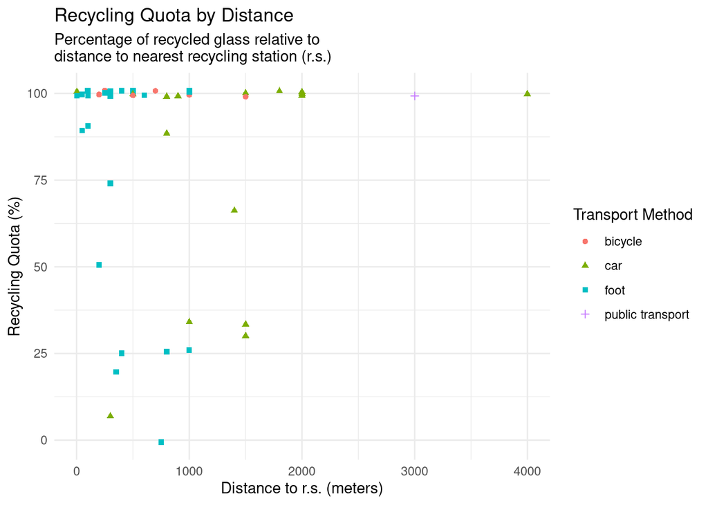

Figure 1: Percentage of recycled glass by distance to recycling station

```r
distance_plot <- clean_data
ggplot(distance_plot,
       mapping = aes(x = travel_distance,
                     y = recycling_percentage,
                     color = transport_method,
                     shape = transport_method
                     )) +
  geom_point(position = position_jitter()) +
  labs(title = "Recycling Quota by Distance",
    subtitle = "Percentage of recycled glass relative to\ndistance to nearest recycling station (r.s.)",
    x = "Distance to r.s. (meters)",
    y = "Recycling Quota (%)",
    color = "Transport Method",
    shape = "Transport Method") +
  theme_minimal()
write.csv(distance_plot, "/cloud/project/data/final/distance_plot.csv")
```

In Figure 1 it is not possible to detect a correlation between the living distance and the recycling rate of the participants, which would suggest that the living distance does not affect the recycling habits of the participants. It can be seen that the participants living further from a recycling station tend to prefer traveling there by car, which was to be expected. The preferred methods of transportation is by foot and by car, which makes sense when one considers the challenges of transporting heavy bags by bike.

```r
distance_tbl %>%
    gt() %>%
    cols_hide(columns = X) %>%
    tab_header(title = "Glass recycling key variables",
               subtitle = "Glass recycling quota grouped by distance to nearest recycling station.") %>%
    fmt_number(columns = mean.bought.bottles:sd.recycling.quota, decimals = 1) %>%
    cols_label(distance_group = "living distance",
               mean.bought.bottles = "mean bought bottles",
               mean.recycled.bottles = "mean recycled bottles",
               mean.recycling.quota = "mean recycling quota",
               sd.recycling.quota = "sd recycling quota")
```

Table 1

Glass recycling key variables

Glass recycling quota grouped by distance to nearest recycling station.

| living distance | count | mean bought bottles | mean recycled bottles | mean recycling quota | sd recycling quota |
| --- | --- | --- | --- | --- | --- |
| 0 - 500m | 26 | 1.9 | 1.7 | 86.8 | 27.9 |
| 501 - 1000m | 14 | 1.8 | 1.3 | 76.5 | 37.3 |
| 1001 - 2000m | 11 | 1.6 | 1.4 | 84.5 | 28.0 |
| 2000m + | 2 | 0.7 | 0.7 | 100.0 | 0.0 |

The count of participants, the mean of glass containers bought and recycled and the mean and standard deviattion of the recycling quota grouped by living distance to the nearest recycling station.

In Table 1 it can be seen that the recycling quota is above 75% for all groups. On average, participants buy just shy of 2 glass container per week. The majority of participants live within a kilometer from the next recycling station, with the maximum distance being 4 kilometers reported by one participant.

## Demographics

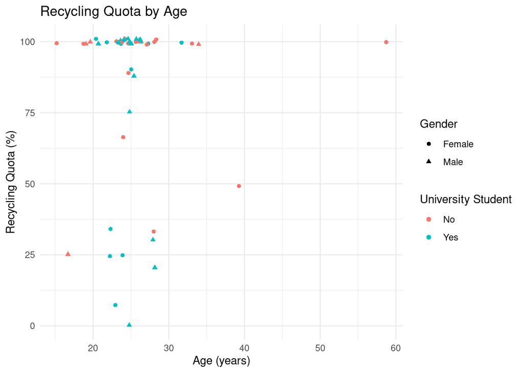

Figure 2: Percentage of recycled glass by age of participants

```r
age_plot <- clean_data

ggplot(age_plot,
       mapping = aes(x = age,
                     y = recycling_percentage,
                     shape = gender,
                     color = student_state
                     )) +
  geom_point(position = position_jitter()) +
  labs(title = "Recycling Quota by Age",
    #subtitle = "Percentage of recycled glass relative to\nage of participants",
    x = "Age (years)",
    y = "Recycling Quota (%)",
    shape = "Gender",
    color = "University Student") +
  theme_minimal()
write.csv(age_plot, "/cloud/project/data/final/age_plot.csv")
```

Figure 2 suggests that people in their twenties are the worst at recycling, but that is probably just because that age group represents the vast majority of participants. Similar arguments can be made for the apparent findings that women and students recycle a lower percentage of their glass waste than men and non-students respectively; they represent the larger part of the sample group.

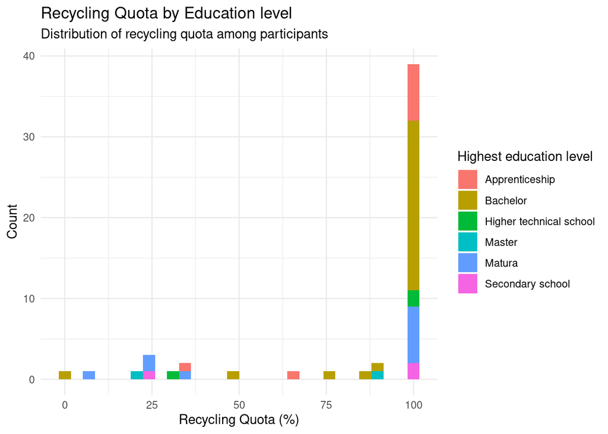

Figure 3: Distribution of recycling quota among participants by education level

```r
edu_plot <- clean_data
ggplot(edu_plot,
      mapping = aes(x = recycling_percentage,
                    fill = edu_lvl)) +
geom_histogram() +
    labs(title = "Recycling Quota by Education level",
    subtitle = "Distribution of recycling quota among participants",
    x = "Recycling Quota (%)",
    y = "Count",
    fill = "Highest education level") +
  theme_minimal()
write.csv(edu_plot, "/cloud/project/data/final/edu_plot.csv")
```

Figure 3 shows that the vast majority of the participants recycles all of their glass waste. A difference based on the highest education level cannot be observed. The high recycling percentage seems very realistic, as, according to Vetroswiss (2023), 97% of all glass waste gets recycled in Switzerland.

## Opinions on measures for improving recycling rate

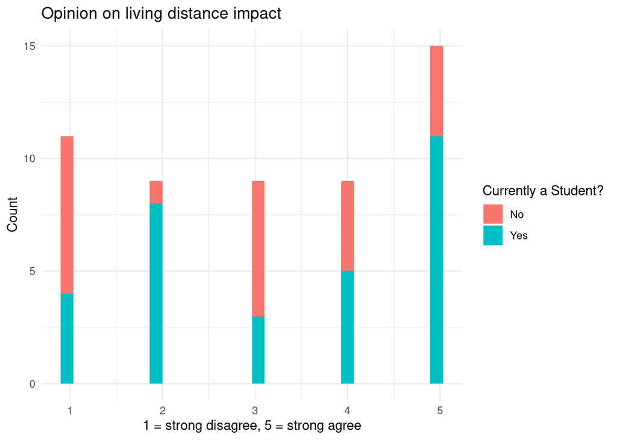

Figure 4: Agreement of participants to statement:would recycle more if my way to the next recycling station was shorter.

```r
dist_opi_plot <- clean_data

ggplot(dist_opi_plot,
      mapping = aes(x = distance_opinion,
                    fill = student_state)) +
geom_histogram() +
    labs(title = "Opinion on living distance impact",
    x = "1 = strong disagree, 5 = strong agree",
    y = "Count",
    fill = "Currently a Student?") +
  theme_minimal()
write.csv(dist_opi_plot, "/cloud/project/data/final/dist_opi_plot.csv")
```

In Figure 4, participants were asked wether living closer to a recycling station would motivate them to recycle more of their glass waste. The responses ver evenly distributed from “strongly disagree” to “strongly agree” with an ever so slight bias towards “strongly agree”. A possible explanation might be that most participants already recycle all of their glass waste, which is why they couldn’t recycle more even if they wanted to.

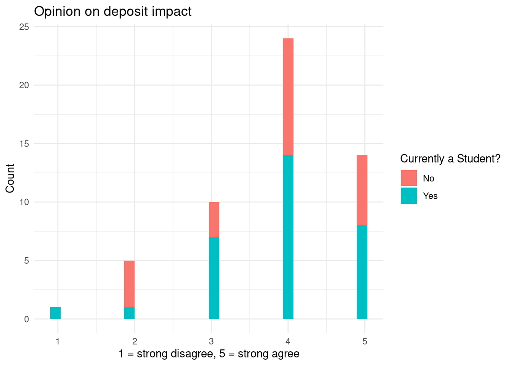

Figure 5: Agreement of participants to statement:you think a deposit on glass bottles would increase the percentage of bottles being returned correctly for recycling?

```r
dep_opi_plot <- clean_data
ggplot(dep_opi_plot,
      mapping = aes(x = deposit_opinion,
                    fill = student_state)) +
geom_histogram() +
    labs(title = "Opinion on deposit impact",
    x = "1 = strong disagree, 5 = strong agree",
    y = "Count",
    fill = "Currently a Student?") +
  theme_minimal()
write.csv(dep_opi_plot, "/cloud/project/data/final/dep_opi_plot.csv")
```

When asked about another measure for increasing the recycling rate, a deposit on glass containers that you only get back when you return the container, the participants showed to be clearly in favour, as is shown in Figure 5. Support for the deposit idea is congruent with a study done in croatia (Šmaguc, Kuštelega, and Kuštelega (2023)). In contrast to the statement regarding the living distance, the statement on the deposit scheme was formulated more broadly, asking about the impact on the general recycling rate instead of the individual recycling behaviour. This different formulation might have influenced the results and should be avoided in the future.

# Conclusions

## References

Šmaguc, Tamara, Magdalena Kuštelega, and Marija Kuštelega. 2023. “THE DETERMINANTS OF INDIVIDUAL’s RECYCLING BEHAVIOR WITH AN INVESTIGATION INTO THE POSSIBILITY OF EXPANDING THE DEPOSIT REFUND SYSTEM IN GLASS WASTE MANAGEMENT IN CROATIA*.” *Management (Croatia)* 28. https://doi.org/10.30924/mjcmi.28.1.6.

Vetropack. 2010. “Glas Bleibt Glas.”

Vetroswiss. 2023. “Faktenblatt Verwertungsquote 2022.” BAFU. https://www.vetroswiss.ch/glasrecycling/zahlen-und-fakten/.